# FinalProjectPML

Alejandro Coy

2019-03-04

## Prediction Weight Lifting

### Background :

Using devices such as Jawbone Up, Nike FuelBand, and Fitbit it is now possible to collect a large amount of data about personal activity relatively inexpensively. These type of devices are part of the quantified self movement – a group of enthusiasts who take measurements about themselves regularly to improve their health, to find patterns in their behavior, or because they are tech geeks. One thing that people regularly do is quantify how much of a particular activity they do, but they rarely quantify how well they do it. In this project, your goal will be to use data from accelerometers on the belt, forearm, arm, and dumbell of 6 participants. They were asked to perform barbell lifts correctly and incorrectly in 5 different ways.

### Data Wrangling

The first task is to load the training and testing data sets. Then we study the dataset using str() funciton from dplyr package.

```
## Classes 'spec_tbl_df', 'tbl_df', 'tbl' and 'data.frame': 19622 obs. of  160 variables:
##  $ X1                      : num  1 2 3 4 5 6 7 8 9 10 ...
##  $ user_name               : chr  "carlitos" "carlitos" "carlitos" "carlitos" ...
##  $ raw_timestamp_part_1    : num  1.32e+09 1.32e+09 1.32e+09 1.32e+09 1.32e+09 ...
##  $ raw_timestamp_part_2    : num  788290 808298 820366 120339 196328 ...
##  $ cvtd_timestamp          : chr  "05/12/2011 11:23" "05/12/2011 11:23" "05/12/2011 11:23" "05/12/2011 11:23" ...
##  $ new_window              : chr  "no" "no" "no" "no" ...
##  $ num_window              : num  11 11 11 12 12 12 12 12 12 12 ...
##  $ roll_belt               : num  1.41 1.41 1.42 1.48 1.48 1.45 1.42 1.42 1.43 1.45 ...
##  $ pitch_belt              : num  8.07 8.07 8.07 8.05 8.07 8.06 8.09 8.13 8.16 8.17 ...
##  $ yaw_belt                : num  -94.4 -94.4 -94.4 -94.4 -94.4 -94.4 -94.4 -94.4 -94.4 -94.4 ...
##  $ total_accel_belt        : num  3 3 3 3 3 3 3 3 3 3 ...
##  $ kurtosis_roll_belt      : chr  NA NA NA NA ...
##  $ kurtosis_picth_belt     : chr  NA NA NA NA ...
##  $ kurtosis_yaw_belt       : chr  NA NA NA NA ...
##  $ skewness_roll_belt      : chr  NA NA NA NA ...
##  $ skewness_roll_belt.1    : chr  NA NA NA NA ...
##  $ skewness_yaw_belt       : chr  NA NA NA NA ...
##  $ max_roll_belt           : num  NA NA NA NA NA NA NA NA NA NA ...
##  $ max_picth_belt          : num  NA NA NA NA NA NA NA NA NA NA ...
##  $ max_yaw_belt            : chr  NA NA NA NA ...
##  $ min_roll_belt           : num  NA NA NA NA NA NA NA NA NA NA ...
##  $ min_pitch_belt          : num  NA NA NA NA NA NA NA NA NA NA ...
##  $ min_yaw_belt            : chr  NA NA NA NA ...
##  $ amplitude_roll_belt     : num  NA NA NA NA NA NA NA NA NA NA ...
##  $ amplitude_pitch_belt    : num  NA NA NA NA NA NA NA NA NA NA ...
##  $ amplitude_yaw_belt      : chr  NA NA NA NA ...
##  $ var_total_accel_belt    : num  NA NA NA NA NA NA NA NA NA NA ...
##  $ avg_roll_belt           : num  NA NA NA NA NA NA NA NA NA NA ...
##  $ stddev_roll_belt        : num  NA NA NA NA NA NA NA NA NA NA ...
##  $ var_roll_belt           : num  NA NA NA NA NA NA NA NA NA NA ...
##  $ avg_pitch_belt          : num  NA NA NA NA NA NA NA NA NA NA ...
##  $ stddev_pitch_belt       : num  NA NA NA NA NA NA NA NA NA NA ...
##  $ var_pitch_belt          : num  NA NA NA NA NA NA NA NA NA NA ...
##  $ avg_yaw_belt            : num  NA NA NA NA NA NA NA NA NA NA ...
##  $ stddev_yaw_belt         : num  NA NA NA NA NA NA NA NA NA NA ...
##  $ var_yaw_belt            : num  NA NA NA NA NA NA NA NA NA NA ...
##  $ gyros_belt_x            : num  0 0.02 0 0.02 0.02 0.02 0.02 0.02 0.02 0.03 ...
##  $ gyros_belt_y            : num  0 0 0 0 0.02 0 0 0 0 0 ...
##  $ gyros_belt_z            : num  -0.02 -0.02 -0.02 -0.03 -0.02 -0.02 -0.02 -0.02 -0.02 0 ...
```

[output cut: 215 more lines]

[output not shown]

The goal of the projet is to predict the maner in which the person lift the weight. This information is avaialbe in the column “classe”. In order to able to run the models we transforms this column to factor.

After futher exploration is determined that not all columns we will be useful due to the amount of missing data. For this reason these columns were dropped from both training and testing data set.

```r
training$classe <- factor(training$classe)

training <- training %>%
  select(-c(1:7))%>%
select(matches("^roll|^pitch|^yaw|^total|^gyros|^accel|^magnet"), classe)
validation <- validation %>%
  select(-c(1:7))%>%
  select(matches("^roll|^pitch|^yaw|^total|^gyros|^accel|^magnet"))
```

### Model Selection

The first step it is to split the the training set further in training and testing. The testing set provided does not contain the outcome, so for this reason it is not useful to test our model. This data set is considered validation set.

```r
train_df <- createDataPartition(training$classe, p =0.7, list = FALSE)
train1 <- training[train_df,]
test1 <- training[-train_df,]
```

The next step is to create a unique train control method. This allow us to make a fair comparision between the models.

```r
trControl <- trainControl(method = "cv", number = 5)
```

### Model1: Recursive Partitioning for Classification(rpart)

First we will implement the simple tree classification using caret and the rpart function. We test the quality of the model using the confussinMatrix function from the caret packgage.

```r
model1 <- train(classe ~. ,data = train1, method ="rpart", trControl =trControl )
p1 <- predict(model1, test1)
confusionMatrix(p1,test1$classe)
```

```
## Confusion Matrix and Statistics
##
##           Reference
## Prediction    A    B    C    D    E
##          A 1517  466  473  422  157
##          B   28  380   36  182  148
##          C  125  293  517  360  285
##          D    0    0    0    0    0
##          E    4    0    0    0  492
##
## Overall Statistics
##
##                Accuracy : 0.4938
##                  95% CI : (0.4809, 0.5067)
##     No Information Rate : 0.2845
##     P-Value [Acc > NIR] : < 2.2e-16
##
##                   Kappa : 0.3388
##  Mcnemar's Test P-Value : NA
##
## Statistics by Class:
##
##                      Class: A Class: B Class: C Class: D Class: E
## Sensitivity            0.9062  0.33363  0.50390   0.0000  0.45471
## Specificity            0.6395  0.91698  0.78123   1.0000  0.99917
## Pos Pred Value         0.4998  0.49096  0.32722      NaN  0.99194
## Neg Pred Value         0.9449  0.85150  0.88177   0.8362  0.89052
## Prevalence             0.2845  0.19354  0.17434   0.1638  0.18386
## Detection Rate         0.2578  0.06457  0.08785   0.0000  0.08360
## Detection Prevalence   0.5157  0.13152  0.26848   0.0000  0.08428
## Balanced Accuracy      0.7729  0.62530  0.64256   0.5000  0.72694
```

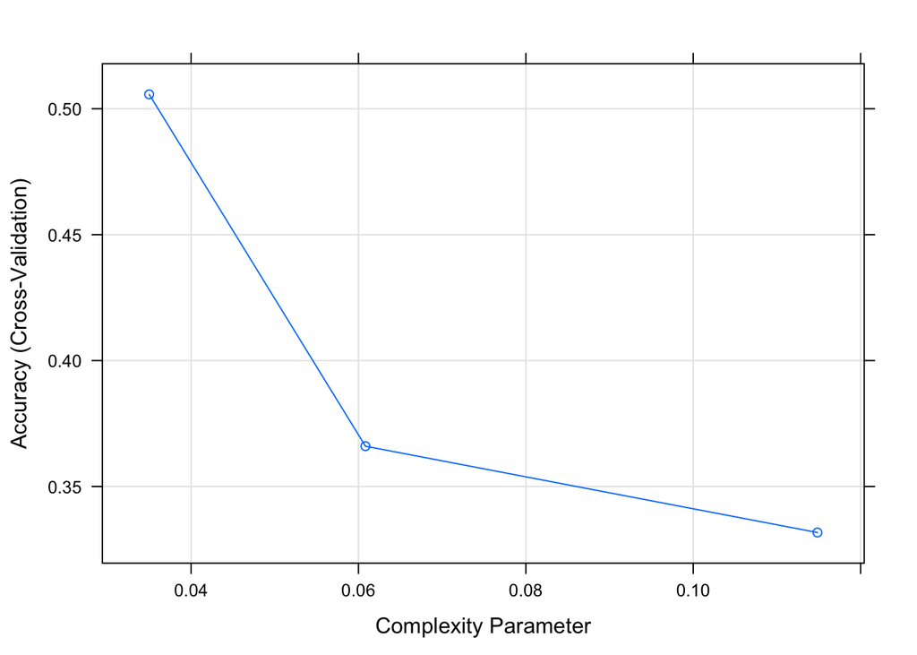

```r
plot(model1)
```

For this data set this simple approach lead to very low accuracy, it is even worse than 50% random guess.

### Model2: Random Forest

The second approch is to use the ramdom forest where multiple tree decission trees are evaluated simulstaniously.

```r
model2 <- train(classe ~. ,data = train1, method ="rf", trControl =trControl,verbose = FALSE)
p2 <- predict(model2, test1)
confusionMatrix(p2,test1$classe)
```

```
## Confusion Matrix and Statistics
##
##           Reference
## Prediction    A    B    C    D    E
##          A 1668    5    0    0    0
##          B    6 1134    2    0    1
##          C    0    0 1024   17    0
##          D    0    0    0  947    2
##          E    0    0    0    0 1079
##
## Overall Statistics
##
##                Accuracy : 0.9944
##                  95% CI : (0.9921, 0.9961)
##     No Information Rate : 0.2845
##     P-Value [Acc > NIR] : < 2.2e-16
##
##                   Kappa : 0.9929
##  Mcnemar's Test P-Value : NA
##
## Statistics by Class:
##
##                      Class: A Class: B Class: C Class: D Class: E
## Sensitivity            0.9964   0.9956   0.9981   0.9824   0.9972
## Specificity            0.9988   0.9981   0.9965   0.9996   1.0000
## Pos Pred Value         0.9970   0.9921   0.9837   0.9979   1.0000
## Neg Pred Value         0.9986   0.9989   0.9996   0.9966   0.9994
## Prevalence             0.2845   0.1935   0.1743   0.1638   0.1839
## Detection Rate         0.2834   0.1927   0.1740   0.1609   0.1833
## Detection Prevalence   0.2843   0.1942   0.1769   0.1613   0.1833
## Balanced Accuracy      0.9976   0.9969   0.9973   0.9910   0.9986
```

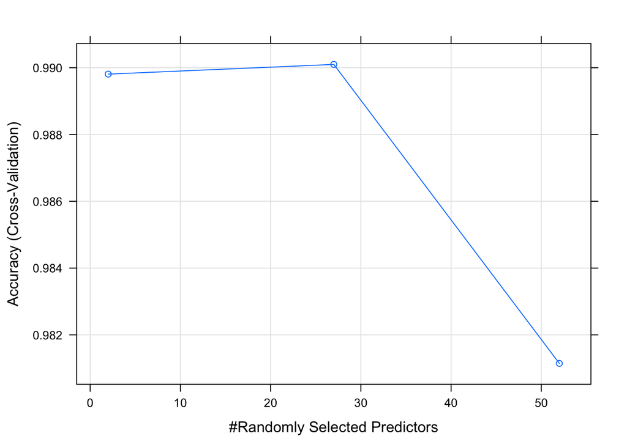

```r
plot(model2)
```

### Model3: Gradient Boosting Machine (gbm)

Althouhg random forest seems like already a very accurate solution, the gbm method was tested.

```r
model3 <- train(classe ~. ,data = train1, method ="gbm", trControl =trControl,verbose = FALSE)
p3 <- predict(model3, test1)
confusionMatrix(p3,test1$classe)
```

```
## Confusion Matrix and Statistics
##
##           Reference
## Prediction    A    B    C    D    E
##          A 1645   37    0    0    1
##          B   18 1071   37    3   14
##          C    6   27  985   31   12
##          D    3    0    4  924   10
##          E    2    4    0    6 1045
##
## Overall Statistics
##
##                Accuracy : 0.9635
##                  95% CI : (0.9584, 0.9681)
##     No Information Rate : 0.2845
##     P-Value [Acc > NIR] : < 2.2e-16
##
##                   Kappa : 0.9538
##  Mcnemar's Test P-Value : 3.88e-09
##
## Statistics by Class:
##
##                      Class: A Class: B Class: C Class: D Class: E
## Sensitivity            0.9827   0.9403   0.9600   0.9585   0.9658
## Specificity            0.9910   0.9848   0.9844   0.9965   0.9975
## Pos Pred Value         0.9774   0.9370   0.9284   0.9819   0.9886
## Neg Pred Value         0.9931   0.9857   0.9915   0.9919   0.9923
## Prevalence             0.2845   0.1935   0.1743   0.1638   0.1839
## Detection Rate         0.2795   0.1820   0.1674   0.1570   0.1776
## Detection Prevalence   0.2860   0.1942   0.1803   0.1599   0.1796
## Balanced Accuracy      0.9868   0.9626   0.9722   0.9775   0.9817
```

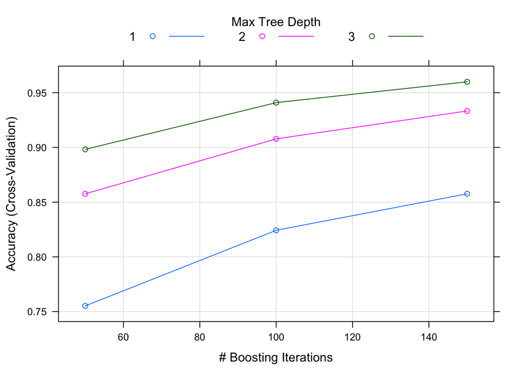

```r
plot(model3)
```

### Using the validation set

Finally we will use the random forest model in our validation set to be able to predict the 20 new data points:

```r
pfinal <- predict(model2, newdata = validation)
pfinal
```

```
##  [1] B A B A A E D B A A B C B A E E A B B B
## Levels: A B C D E
```